# CS559: Homework #2

### Due:10/8/2021 Friday 11:59 PM

- Change the file name as YourName_F21_CS559_HW2
- Submit the assignment in `ipynb` and `html` formats.
  - You can export the notebook in HTML.
  - Do not compress your files. Please submit files individually.
- All work must be your own and must not be shared with other classmates.
  - Collaboration with classmates or getting help by any people is not acceptable.
  - For impletementation problems, do not copy algorithms from internet.

### Problem 1 - Linear Regression [35 pts]

1-a. Consider a data set in which each data point $t_n$ is associated with a weighting factor $r_n>0$, so that the sum of squares error function becomes

$${\large E_D(\vec{w})=\frac{1}{2}\sum_{n=1}^Nr_n\big(t_n-\vec{w}^T\vec{x}_n\big)^2}$$

Find an expression for the solution $w^*$ that minimizes this error function. [5 pts]

```python
### my_LR starts here - are we implementing my_error or my_LR?  again, this is very confusing
#where is W is we are only passing data and learning rate?  This question is very confusing in how it is worded.
# def my_error(data,r_n):
#     for r in r_n:
#         w = r * (data -)
#         error =

#     return w, error, r_n
from sklearn.metrics import mean_squared_error

class my_LinearRegression:
    def __init__(self, learning_rate = .01, iterations = 100):
        self.learning_rate = learning_rate
        self.iterations = iterations

    def fit(self, X, y):
        num_features = X.shape[1]
        num_rows = X.shape[0]
        self.weights = np.zeros((num_features,))

        for it in range(self.iterations):
            for idx in range(num_rows):
                x = X[idx]
                y_true = y[idx]
                pred = self.predict(x)
                error = pred - y_true
                cost = 1/(2*num_rows) * np.dot(error.T, error)
                self.weights = self.weights - (self.learning_rate * (1/num_rows) * (x * error))
        return self.weights

    def predict(self, X):
        return np.dot(X, self.weights)

    def get_error(self, X, y):
        pred = self.predict(X)
        mse = mean_squared_error(y, pred)
        return mse
```

1-b. Implement a function called, `my_error(data,r_n)`, that estimates the error using the error function, $E_D(\vec{w})$, from 1-a. The task to implement a function to estimates the optimized $vec{w}$ and demonstrates the behavior of error at different weighting factor, $r_n$, values. The function return a list of $\vec{w}$, $r_n$, and error. Do not use any other modules except `numpy`. [10 pts]

```python
def my_error(X, y, r_n):
    mse_list = []
    w_list = []
    for r in r_n:
        print(f'{r}')
        lr = my_LinearRegression()
        lr.fit(X, y)
        mse = lr.get_error(X, y)
        mse_list.append(mse)
        w_list.append(lr.weights)
    return mse_list, w_list, r_n
```

1-c. Load the dataset, make a model using Linear Regression from sklearn.linear_model to predict the target `y` from a given dataset `HW2_LR.csv`. Students must do EDA and pre-processing the dataset before training the model. All pre-processing and EDA work must be explained and the weights and mean squared error value must be reported. Treat the whole dataset as a train set. [15 pts]

```python
from sklearn.linear_model import LinearRegression
from sklearn.metrics import mean_squared_error
import matplotlib.pyplot as plt
from pandas.plotting import scatter_matrix
from sklearn.preprocessing import StandardScaler
import pandas as pd
import numpy as np
```

```python
data = pd.read_csv('./HW2_LR.csv')
```

```
<class 'pandas.core.frame.DataFrame'>
RangeIndex: 10000 entries, 0 to 9999
Data columns (total 6 columns):
 #   Column  Non-Null Count  Dtype
---  ------  --------------  -----
 0   a       10000 non-null  float64
 1   b       10000 non-null  float64
 2   c       10000 non-null  float64
 3   d       10000 non-null  float64
 4   k       10000 non-null  float64
 5   y       10000 non-null  float64
dtypes: float64(6)
memory usage: 468.9 KB
None
```

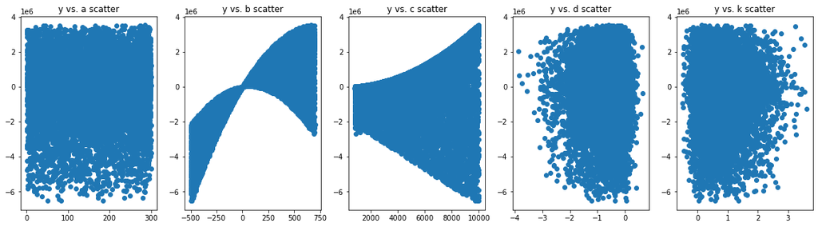

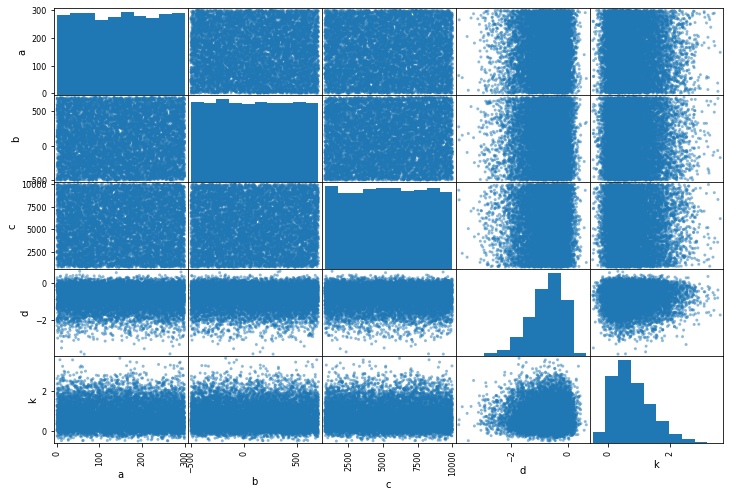

```python
### EDA stars here
print(data.info())
fig, ax = plt.subplots(1, len(data.columns)-1, figsize = (20,5))
y = data.y.values
for idx, c in enumerate(data.columns):
    if c == 'y':
        continue
    x = data[c].values
    ax[idx].scatter(x, y)
    ax[idx].set_title(f'y vs. {c} scatter')
scatter_matrix(data[[i for i in data.columns if i != 'y']], figsize=(12,8))
plt.show()
```

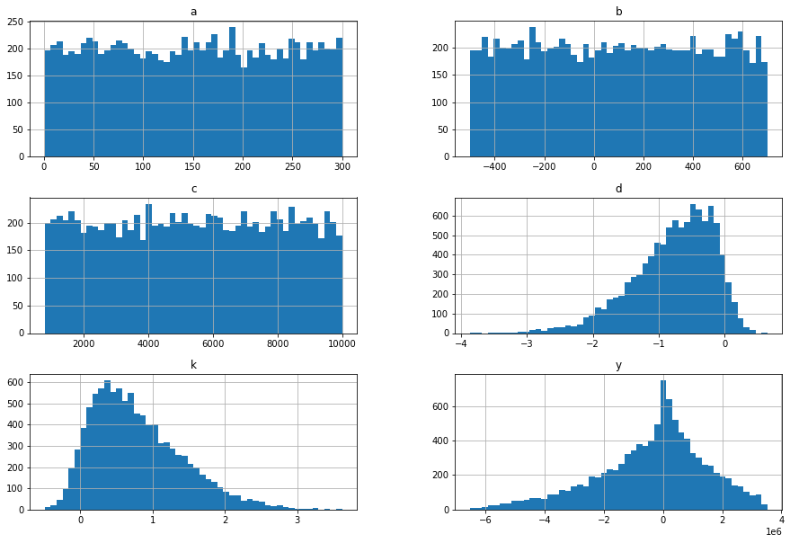

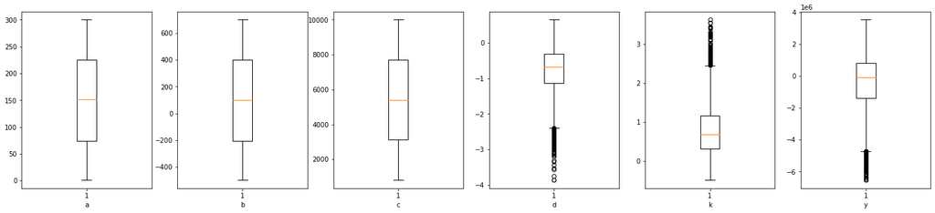

```python
data.hist(bins = 50, figsize = (15, 10))
plt.show()

fig, ax = plt.subplots(1, len(data.columns), figsize = (25, 5))
for idx, c in enumerate(data.columns):
    ax[idx].boxplot(data[c])
    ax[idx].set_xlabel(c)
plt.show()
```

```python
# !pip install seaborn
```

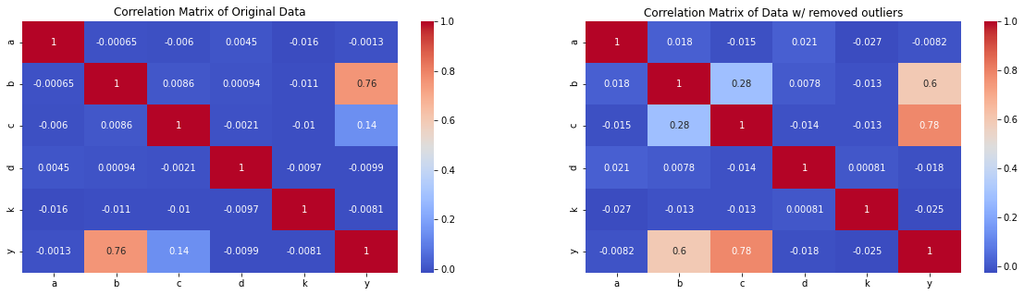

```python
# assert False
import seaborn as sns

fig, ax = plt.subplots(1, 2, figsize = (20, 5))
ax[0].set_title('Correlation Matrix of Original Data')
correlation_matrix = data.corr()
sns.heatmap(correlation_matrix, ax = ax[0], cmap = 'coolwarm', xticklabels = correlation_matrix.columns, yticklabels = correlation_matrix.columns, annot= True)

ax[1].set_title('Correlation Matrix of Data w/ removed outliers')
outliers_removed = data[(data.d >= -2.5) & (data.k <= 2.5) & (data.y >= -4.5)]
correlation_matrix_new = outliers_removed.corr()
sns.heatmap(correlation_matrix_new, ax = ax[1], cmap = 'coolwarm', xticklabels = correlation_matrix_new.columns, yticklabels = correlation_matrix_new.columns, annot= True)
```

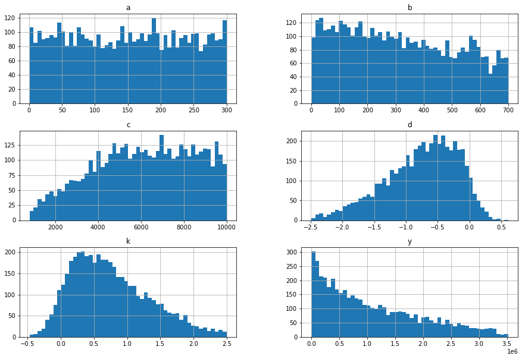

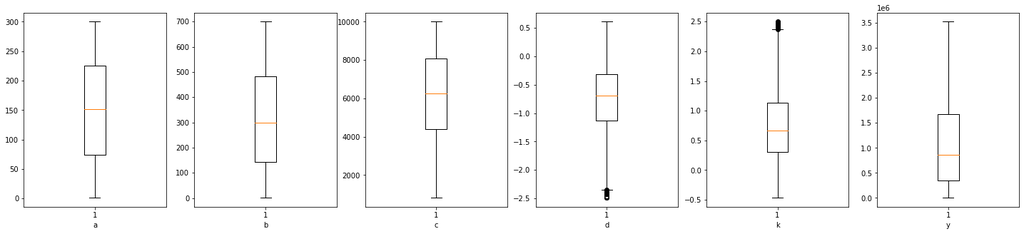

```python
outliers_removed.hist(bins = 50, figsize = (15, 10))
plt.show()

fig, ax = plt.subplots(1, len(outliers_removed.columns), figsize = (25, 5))
for idx, c in enumerate(outliers_removed.columns):
    ax[idx].boxplot(outliers_removed[c])
    ax[idx].set_xlabel(c)
plt.show()
```

#### Feature Selection

```python
### Pre-processing starts here
target = data[['y']].values
feature_columns = ['b', 'c'] #include only these because they are correlated with the target values and they are not correlated with other columns
features = data[feature_columns]
scaler = StandardScaler()
features_scaled = {}
for c in features.columns:
    d = scaler.fit_transform(features[c].values.reshape(-1, 1))
    features_scaled[c] = d.ravel()
features_scaled = pd.DataFrame(features_scaled, index = [i for i in range(len(features_scaled[list(features_scaled.keys())[0]]))]).values
```

```python
### Linear Regression Modeling starts here
LR = LinearRegression()
LR.fit(features_scaled, target)
y_pred = LR.predict(features_scaled)
lr_mse = mean_squared_error(target, y_pred)
print(f'MSE: {lr_mse}')
print(f'Coefficients (w): {LR.coef_}')
```

```
MSE: 1382075137479.9707
Coefficients (w): [[1394355.26627821  252658.95396281]]
```

1-d. Use the function `my_error()` from 1-b to estimate $\vec{w}$ and make a visualization to show the behavior of error in terms of $r_n$. Add a point to indicate the final training model error obtained from 1-c. [5 pts]

```
1
0.5
0.1
0.001
0.0001
```

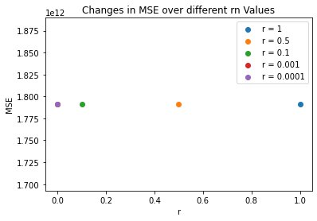

```python
### Visualization starts from here.
#this makes no sense - LinearRegression in Sklearn does not use lr.  RidgeRegression, Lasso, Etc do.  How do we plot MSE against lr if the function
#has no R.  These first few questions are very confusing.

def visualize_lr_change():
    mse_list, _, r_n = my_error(features_scaled, target, [1, .5, .1, .001, .0001])
    for mse, r in zip(mse_list, r_n):
        plt.scatter(r, mse, label = f'r = {r}')
    plt.title('Changes in MSE over different rn Values')
    plt.legend()
    plt.xlabel('r')
    plt.ylabel('MSE')
    plt.show()
visualize_lr_change()
```

### Problem 2 - Linear Classification 1 [65 pts]

In this assignment, you are going to implement three classifiers - **LDA, Perceptron, and Logistic Regression** - to predict the risk of heart attack using the provided dataset, `heart.csv`.

Here are data attributes:

- Age : Age of the patient
- Sex : Sex of the patient
- exang: exercise induced angina (1 = yes; 0 = no)
- ca: number of major vessels (0-3)
- cp : Chest Pain type chest pain type
  - Value 1: typical angina
  - Value 2: atypical angina
  - Value 3: non-anginal pain
  - Value 4: asymptomatic
- trtbps : resting blood pressure (in mm Hg)
- chol : cholestoral in mg/dl fetched via BMI sensor
- fbs : (fasting blood sugar > 120 mg/dl) (1 = true; 0 = false)
- restecg : resting electrocardiographic results
  - Value 0: normal
  - Value 1: having ST-T wave abnormality (T wave inversions and/or ST elevation or depression of > 0.05 mV)
  - Value 2: showing probable or definite left ventricular hypertrophy by Estes' criteria
- thalach : maximum heart rate achieved
- output : 0= less chance of heart attack 1= more chance of heart attack

2-a. Implement `my_LDA` that classifies the target. Use `accuracy_score` from `sklearn.metrics` to calculate the accuracy. [10 pts]

```python
from sklearn.metrics import accuracy_score
import numpy as np

data = pd.read_csv('heart.csv')
features = data[[i for i in data.columns if i != 'output']].values
target = data[['output']].values
```

```python
### my_LDA starts here
class my_LDA:
    def __init__(self, n_components = 2):
        self.n_components = 2
    def fit(self, features, target):
        height, width = features.shape
        unique_classes = np.unique(target)
        num_classes = len(unique_classes)

        scatter_t = np.cov(features.T)*(height - 1)
        scatter_w = 0
        for i in range(num_classes):
            class_items = np.flatnonzero(target == unique_classes[i])
            scatter_w = scatter_w + np.cov(features[class_items].T) * (len(class_items)-1)

        scatter_b = scatter_t - scatter_w
        _, eig_vectors = np.linalg.eigh(np.linalg.pinv(scatter_w).dot(scatter_b))

        self.eig_vectors = eig_vectors

    def predict(self, x):
        p = x.dot(self.eig_vectors[:,::-1][:,:self.n_components])
        return np.argmax(p, axis = 1)

    def get_accuracy(self, x, y_true):
        p = self.predict(x)
        accuracy = accuracy_score(y_true, p)
        return accuracy
```

2-b. Implement `my_Perceptron` that classifies the target. Use `accuracy_score` from `sklearn.metrics` to calculate the accuracy. [10 pts]

```python
class my_Perceptron:
    def __init__(self, learning_rate = .5, iterations = 10000):
        self.learning_rate = learning_rate
        self.iterations = iterations
        self.bias = 0
        self.checkpoint_weights = 0
        self.checkpoint_bias = 0
        self.max_accuracy = 0

    def activation(self, x):
        return 1 if np.dot(self.weights, x) >= self.bias else 0

    def predict(self, x):
        predict = []
        for row in x:
            predict.append(self.activation(row))
        return predict

    def get_accuracy(self, x, y_true):
        prediction = self.predict(x)
        return accuracy_score(y_true, prediction)

    def fit(self, X, y):
        num_features = X.shape[1]
        self.weights = np.zeros((num_features,))
        num_rows = X.shape[0]
        for it in range(self.iterations):
            error_sum = 0
            for idx in range(num_rows):
                y_true = y[idx]
                row = X[idx]
                y_hat = self.activation(row)
                error = y_true-y_hat
                if error != 0:
                    self.weights = self.weights + (self.learning_rate * error) * row
                    self.bias = self.bias + (self.learning_rate * error * -1)

            accuracy = self.get_accuracy(X, y)
            print(f'Epoch {it} | Accuracy: {accuracy}', end = '\r')
            if accuracy >= self.max_accuracy:
                self.checkpoint_bias = self.bias
                self.checkpoint_weights = self.weights.copy()
                self.max_accuracy = accuracy
        self.bias = self.checkpoint_bias
        self.weights = self.checkpoint_weights
        print(f'Max Accuracy: {self.max_accuracy}')

        return self.weights, self.bias
# perceptron = my_Perceptron()
# best_weights, best_bias = perceptron.fit(features, target)
```

2-c. Implement `my_LogisticRegression` that classifies the target. Use `accuracy_score` from `sklearn.metrics` to calculate the accuracy. [10 pts]

```python
### my_LogisticRegression starts here

class my_LogisticRegression:
    def __init__(self, iterations = 100, learning_rate = .1):
        self.iterations = iterations
        self.learning_rate = learning_rate
        self.bias = 0

    def fit(self, features, target, batch_size = 100):
        features = (features - features.mean(axis = 0)) / X.std(axis = 0) #normalize the features
        num_features = features.shape[1]
        m = features.shape[0]
        self.weights = np.zeros((num_features,1))
#         print(features.shape)
        h_stack = np.hstack([features, target])
#         print(h_stack.shape)
        features_split = np.array_split(features, batch_size)
        for it in range(self.iterations):
            sum_error = 0
            for idx in range(len(features_split)-1):
                row = features_split[idx]
                x = row[:, :row.shape[-1]]
                y_true = row[:, -1:]
                y_hat = self.predict(x)
#                 print(x.shape, y_true.shape, y_hat.shape, self.weights.shape)
                #get gradients

                dw = (-1/m) * np.dot(x.T, (y_hat - y_true)) #(x.T * (np.sum(y_true - y_hat, axis = 0)))
                db = (-1/m) * np.sum(y_hat - y_true)
                self.weights = self.weights - self.learning_rate * dw

                self.bias = self.bias - self.learning_rate * db
#                 print('~'*100)

            accuracy = self.get_accuracy(X, y)
            print(f'Iteration {it} | Accuracy: {accuracy}', end = '\r')
    def sigmoid(self, x):
        return 1.0/(1+np.exp(-x))

    def predict(self, x):
        x = np.dot(x, self.weights) + self.bias
        return self.sigmoid(x)

    def get_accuracy(self, x, y_true):
        y_hat = self.predict(x)
        y_hat = [1 if i > .5 else 0 for i in y_hat]
        return accuracy_score(y_true, y_hat)
# my_logistic = my_LogisticRegression()
# my_logistic.fit(features, target)
```

2-d. The EDA and pre-processing are not limitted however, you must

1. check if the data is **balanced** or not.
2. check if features are **skewed** or not.
3. check outliers.

For any finds from 1 to 3, please handle the data carefully. Exaplin your workflow and perform accordingly. If any interesting facts are learned, please state them. [15 pts]

#### Findings

```
<class 'pandas.core.frame.DataFrame'>
RangeIndex: 303 entries, 0 to 302
Data columns (total 14 columns):
 #   Column    Non-Null Count  Dtype
---  ------    --------------  -----
 0   age       303 non-null    int64
 1   sex       303 non-null    int64
 2   cp        303 non-null    int64
 3   trtbps    303 non-null    int64
 4   chol      303 non-null    int64
 5   fbs       303 non-null    int64
 6   restecg   303 non-null    int64
 7   thalachh  303 non-null    int64
 8   exng      303 non-null    int64
 9   oldpeak   303 non-null    float64
 10  slp       303 non-null    int64
 11  caa       303 non-null    int64
 12  thall     303 non-null    int64
 13  output    303 non-null    int64
dtypes: float64(1), int64(13)
memory usage: 33.3 KB
None
1    165
0    138
Name: output, dtype: int64
```

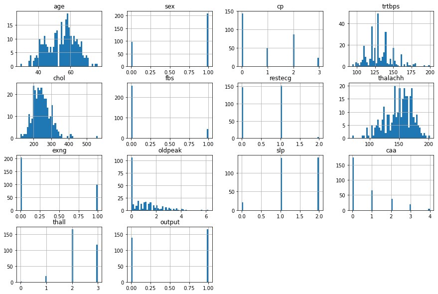

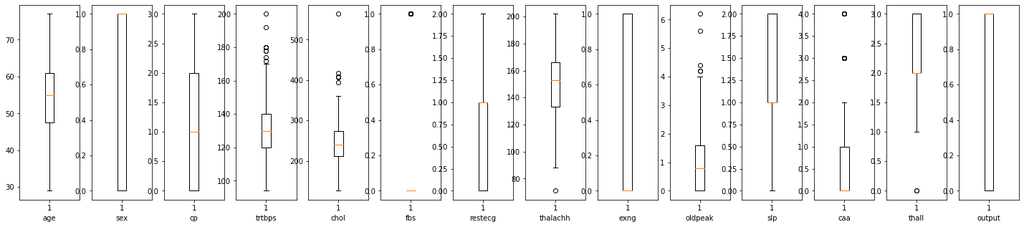

```
1    157
0    129
Name: output, dtype: int64
```

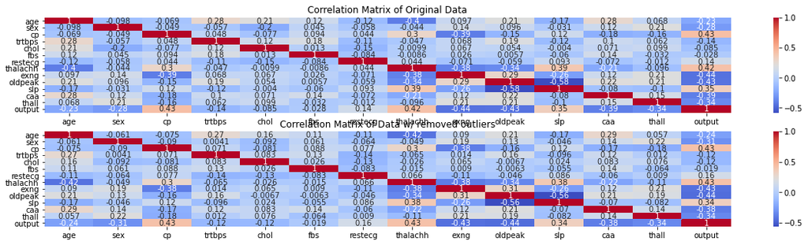

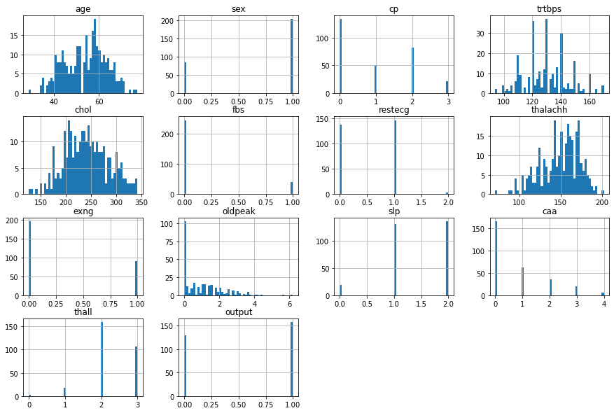

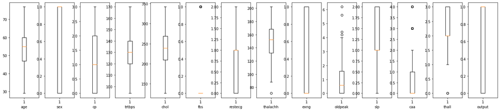

```python
### EDA stars here
print(data.info())
print(data.output.value_counts())
data.hist(bins = 50, figsize = (15, 10))
plt.show()

fig, ax = plt.subplots(1, len(data.columns), figsize = (25, 5))
for idx, c in enumerate(data.columns):
    ax[idx].boxplot(data[c])
    ax[idx].set_xlabel(c)
plt.show()


fig, ax = plt.subplots(2, figsize = (20, 5))
ax[0].set_title('Correlation Matrix of Original Data')
correlation_matrix = data.corr()
sns.heatmap(correlation_matrix, ax = ax[0], cmap = 'coolwarm', xticklabels = correlation_matrix.columns, yticklabels = correlation_matrix.columns, annot= True)

ax[1].set_title('Correlation Matrix of Data w/ removed outliers')
outliers_removed = data[(data.chol <= 350) & (data.trtbps <= 170)]
correlation_matrix_new = outliers_removed.corr()
sns.heatmap(correlation_matrix_new, ax = ax[1], cmap = 'coolwarm', xticklabels = correlation_matrix_new.columns, yticklabels = correlation_matrix_new.columns, annot= True)


print(outliers_removed.output.value_counts())
outliers_removed.hist(bins = 50, figsize = (15, 10))
plt.show()

fig, ax = plt.subplots(1, len(outliers_removed.columns), figsize = (25, 5))
for idx, c in enumerate(outliers_removed.columns):
    ax[idx].boxplot(outliers_removed[c])
    ax[idx].set_xlabel(c)
plt.show()
```

```python
### Pre-processing starts here
features = outliers_removed[['oldpeak', 'age', 'sex', 'cp', 'trtbps', 'chol', 'restecg', 'thalachh', 'exng', 'caa', 'thall']]
target = outliers_removed[['output']]
scaler = StandardScaler()
features_scaled = {}
for c in features.columns:
    d = scaler.fit_transform(features[c].values.reshape(-1, 1))
    features_scaled[c] = d.ravel()
features_scaled = pd.DataFrame(features_scaled, index = [i for i in range(len(features_scaled[list(features_scaled.keys())[0]]))])
X = features.values
y = target.values
```

2-e. Use ML LDA, Perceptron, and LogisticRegression from sklearn to classify the trained data and report the accuracy. [10 pts]

```python
from sklearn.linear_model import LogisticRegression
from sklearn.discriminant_analysis import LinearDiscriminantAnalysis
from sklearn.linear_model import Perceptron
```

```python
### LDA starts here
clf1= LinearDiscriminantAnalysis()
clf1.fit(X, y)
y_pred = clf1.predict(X)
clf1_accuracy = accuracy_score(y,y_pred)
print(f'SKlearn LDA: {clf1_accuracy}')
```

```
SKlearn LDA: 0.8461538461538461
```

```python
### Perceptron starts here
clf2 = Perceptron()
clf2.fit(X, y)
y_pred = clf2.predict(X)
clf2_accuracy = accuracy_score(y,y_pred)
print(f'SKlearn Perceptron: {clf2_accuracy}')
```

```
SKlearn Perceptron: 0.5524475524475524
```

```python
### Logistic Regression starts here
clf3 = LogisticRegression()
clf3.fit(X, y)
y_pred = clf3.predict(X)
clf3_accuracy = accuracy_score(y,y_pred)
print(f'SKlearn Logistic Regression: {clf3_accuracy}')
```

```
SKlearn Logistic Regression: 0.8566433566433567
```

2-f. Use the implemented classifiers from 2-a to 2-c and classify the output. [10 pts]

```python
clf4= my_LDA()
clf4.fit(X, y)
y_pred = clf4.predict(X)
clf4_accuracy = accuracy_score(y,y_pred)
print(f'my_LDA: {clf4_accuracy}')
```

```
my_LDA: 0.548951048951049
```

```python
clf5= my_Perceptron() #default 10000 epochs
clf5.fit(X, y)
y_pred = clf5.predict(X)
clf5_accuracy = accuracy_score(y,y_pred)
print(f'my_Perceptron: {clf5_accuracy}')
```

[output not shown]

```python
clf6= my_LogisticRegression()
clf6.fit(X, y)
y_pred = clf6.predict(X)
y_pred = [1 if i > .5 else 0 for i in y_pred]
clf6_accuracy = accuracy_score(y,y_pred)
print(f'my_LogisticRegression: {clf6_accuracy}')
```

[output not shown]

```python
result_table = pd.DataFrame({'Model':['SK_LDA','SK_Perceptron','SK_Logistic','my_LDA','my_Perceptron','my_LogisticRegression'],
                             'Accuracy': [clf1_accuracy,clf2_accuracy,clf3_accuracy,
                                        clf4_accuracy,clf5_accuracy,clf6_accuracy]})
result_table
```

|  | Model | Accuracy |
| --- | --- | --- |
| 0 | SK_LDA | 0.846154 |
| 1 | SK_Perceptron | 0.552448 |
| 2 | SK_Logistic | 0.856643 |
| 3 | my_LDA | 0.548951 |
| 4 | my_Perceptron | 0.618881 |
| 5 | my_LogisticRegression | 0.660839 |